[GitHub](https://github.com/JuliaGeometry/DelaunayTriangulation.jl)[](https://github.com/JuliaGeometry/DelaunayTriangulation.jl/tree/main/docs/src/literate_tutorials/voronoi.jl)

# Voronoi Tessellations

In this tutorial, we demonstrate how we can construct Voronoi tessellations and work with them. Voronoi tessellations are built from a dual Delaunay triangulation using `voronoi`. To start, let us load in the packages.

```julia
using DelaunayTriangulation
using CairoMakie
using StableRNGs
```

We build the tessellation by constructing the triangulation, and then passing that triangulation into `voronoi`.

```julia
points = [
    (-3.0, 7.0), (1.0, 6.0), (-1.0, 3.0),
    (-2.0, 4.0), (3.0, -2.0), (5.0, 5.0),
    (-4.0, -3.0), (3.0, 8.0)
]
rng = StableRNG(123)
tri = triangulate(points; rng)
vorn = voronoi(tri)
```

```
Voronoi Tessellation.
    Number of generators: 8
    Number of polygon vertices: 9
    Number of polygons: 8
```

To visualise the tessellation, you can use `voronoiplot`. Here, we also compare the tessellation with its dual triangulation.

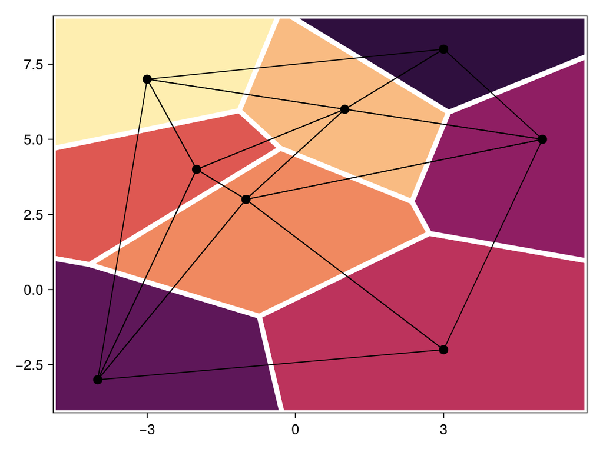

```julia
fig, ax, sc = voronoiplot(vorn, markersize=13, colormap=:matter, strokecolor=:white, strokewidth=5)
triplot!(ax, tri)
fig
```

The polygons each correspond to a *generator*, which is the black point inside it coming from `points`, i.e. the vertices of the triangulation. The polygons are all convex. Note also that the unbounded polygons, those coming from generators on the convex hull of the point set, are clipped in the above plot but in reality they go on to infinity. In the clipping to rectangular regions tutorial, we discuss how these polygons are clipped to a rectangle in more detail.

Let us now demonstrate in more detail how we can work with `vorn`.

## Iterating over generators

The generators are stored in a `Dict`, mapping vertices to coordinates; this is a `Dict` rather than a `Vector` because the original triangulation may not contain all the points, noting that `get_generators(vorn)` is just a repackaged version of `get_points(tri)`. (A separate field is needed so that clipped and centroidal tessellations can add new generators without affecting the points in `tri`.) These generators can be accessed using `get_generators(vorn)`:

```julia
DelaunayTriangulation.get_generators(vorn)
```

```
Dict{Int64, Tuple{Float64, Float64}} with 8 entries:
  5 => (3.0, -2.0)
  4 => (-2.0, 4.0)
  6 => (5.0, 5.0)
  7 => (-4.0, -3.0)
  2 => (1.0, 6.0)
  8 => (3.0, 8.0)
  3 => (-1.0, 3.0)
  1 => (-3.0, 7.0)
```

It is preferred that you use `each_generator(vorn)`, though, which is an iterator over the generators:

```julia
each_generator(vorn)
```

```
KeySet for a Dict{Int64, Tuple{Float64, Float64}} with 8 entries. Keys:
  5
  4
  6
  7
  2
  8
  3
  1
```

Note that this is just the keys of the above `Dict`. To access specific generators, you use `get_generator`. For example,

```julia
get_generator(vorn, 3)
```

```
(-1.0, 3.0)
```

To give an example, here is how we can compute the average generator position.

```julia
function average_generator(vorn)
    cx, cy = 0.0, 0.0
    for i in each_generator(vorn)
        p = get_generator(vorn, i)
        px, py = getxy(p)
        cx += px
        cy += py
    end
    n = num_polygons(vorn) # same as DelaunayTriangulation.num_generators(vorn)
    cx /= n
    cy /= n
    return cx, cy
end
cx, cy = average_generator(vorn)
```

```
(0.25, 3.5)
```

## Iterating over polygon and polygon vertices

You can also look at the individual polygons, and all their vertices. These polygons and their vertices are stored as below:

```julia
DelaunayTriangulation.get_polygons(vorn)
```

```
Dict{Int64, Vector{Int64}} with 8 entries:
  5 => [4, 8, -2, -1, 4]
  4 => [1, 9, 3, 7, 1]
  6 => [-1, -3, 6, 5, 4, -1]
  7 => [8, 1, 7, -5, -2, 8]
  2 => [9, 5, 6, 2, 3, 9]
  8 => [-3, -4, 2, 6, -3]
  3 => [4, 5, 9, 1, 8, 4]
  1 => [3, 2, -4, -5, 7, 3]
```

```julia
DelaunayTriangulation.get_polygon_points(vorn)
```

```
9-element Vector{Tuple{Float64, Float64}}:
 (-4.166666666666666, 0.8333333333333335)
 (-0.2999999999999998, 9.3)
 (-1.1363636363636365, 5.954545454545455)
 (2.710526315789474, 1.868421052631579)
 (2.357142857142857, 2.9285714285714284)
 (3.1, 5.9)
 (-10.807692307692307, 2.730769230769231)
 (-0.7307692307692308, -0.8846153846153846)
 (-0.30000000000000004, 4.7)
```

You should not work with these fields directly, though. If you want to look at a specific polygon, you should use `get_polygon`. For example,

```julia
get_polygon(vorn, 1)
```

```
6-element Vector{Int64}:
  3
  2
 -4
 -5
  7
  3
```

This is a `Vector` of the vertices of the polygon, in counter-clockwise order, and such that the first and last vertices are the same. The vertices refer to points in the `polygon_points` field, which you could then obtain using `get_polygon_point`. For example, the first vertex corresponds to the coordinates:

```julia
get_polygon_point(vorn, 1)
```

```
(-4.166666666666666, 0.8333333333333335)
```

In `get_polygon(vorn, 1)`, notice that there are two negative indices. These negative indices correspond to vertices out at infinity; their actual values do not matter, just that they are negative. Thus, this polygon is actually an unbounded polygon. This can be checked in two ways:

```julia
1 ∈ DelaunayTriangulation.get_unbounded_polygons(vorn)
```

```
true
```

```julia
get_area(vorn, 1) == Inf
```

```
true
```

There are several ways that you can iterate over the polygons. If you want each polygon, then you can use `each_polygon`:

```julia
each_polygon(vorn)
```

```
ValueIterator for a Dict{Int64, Vector{Int64}} with 8 entries. Values:
  [4, 8, -2, -1, 4]
  [1, 9, 3, 7, 1]
  [-1, -3, 6, 5, 4, -1]
  [8, 1, 7, -5, -2, 8]
  [9, 5, 6, 2, 3, 9]
  [-3, -4, 2, 6, -3]
  [4, 5, 9, 1, 8, 4]
  [3, 2, -4, -5, 7, 3]
```

This is an iterator over all the polygon vertices, but you do not get the associated polygon index. If you want an iterator that is over the polygon indices, you use `each_polygon_index`:

```julia
each_polygon_index(vorn)
```

```
KeySet for a Dict{Int64, Vector{Int64}} with 8 entries. Keys:
  5
  4
  6
  7
  2
  8
  3
  1
```

If you did want to have both the indices and the vertices together, you can use `zip` on these two iterators. This would be the same as iterating over the internal `polygons` field, but this could be subject to change in the future. To get an iterator over the polygon vertices rather than caring about a specific polygon, you use `each_polygon_vertex`:

```julia
each_polygon_vertex(vorn)
```

```
Base.OneTo(9)
```

This is just an iterator of the indices to pass into `get_polygon_point`. You can also query the number of polygons and polygon vertices as follows:

```julia
num_polygons(vorn)
```

```
8
```

```julia
num_polygon_vertices(vorn)
```

```
9
```

To give an example of how we might use these iterators, here we compute the area of all polygons.

```julia
function get_polygon_area(vorn, i)
    i ∈ DelaunayTriangulation.get_unbounded_polygons(vorn) && return Inf
    area = 0.0
    vertices = get_polygon(vorn, i)
    vⱼ = vertices[begin]
    pⱼ = get_polygon_point(vorn, vⱼ)
    xⱼ, yⱼ = getxy(pⱼ)
    for j in (firstindex(vertices)+1):lastindex(vertices) # same as 2:length(vertices)
        vⱼ₊₁ = vertices[j]
        pⱼ₊₁ = get_polygon_point(vorn, vⱼ₊₁)
        xⱼ₊₁, yⱼ₊₁ = getxy(pⱼ₊₁)
        area += xⱼ * yⱼ₊₁ - xⱼ₊₁ * yⱼ
        vⱼ, pⱼ, xⱼ, yⱼ = vⱼ₊₁, pⱼ₊₁, xⱼ₊₁, yⱼ₊₁
    end
    return area / 2
end
function get_polygon_areas(vorn)
    areas = zeros(num_polygons(vorn))
    for i in each_polygon_index(vorn)
        areas[i] = get_polygon_area(vorn, i)
    end
    return areas
end
vorn_areas = get_polygon_areas(vorn)
```

```
8-element Vector{Float64}:
 Inf
 14.34935064935065
 20.07578561789088
 23.92237762237762
 Inf
 Inf
 Inf
 Inf
```

Note that this could have also been obtained using `get_area`:

```julia
function direct_polygon_areas(vorn)
    areas = zeros(num_polygons(vorn))
    for i in each_polygon_index(vorn)
        areas[i] = get_area(vorn, i)
    end
    return areas
end
vorn_areas ≈ direct_polygon_areas(vorn)
```

```
true
```

Moreover, note that the following is false:

```julia
vorn_areas ≈ [get_area(vorn, i) for i in each_polygon_index(vorn)]
```

```
false
```

because `each_polygon_index` does not return the polygons in a sorted order.

Before we move on, we emphasise that it is not guaranteed that the values of the vertices for a given polygon are the same if you were to recompute the tessellation. The actual coordinates will all be the same, but they just might correspond to different vertex values. The indices of the polygons will be the same, though, as they are derived from the point indices.

## Getting polygons adjacent to an edge

Given an edge in the tessellation, you can use `get_adjacent` to get the polygon that it is a part of (taking care of order). For example,

```julia
get_adjacent(vorn, 1, 8)
```

```
3
```

means that the edge `(1, 8)` belongs to the third polygon, as we can easily verify:

```julia
get_polygon(vorn, 3)
```

```
6-element Vector{Int64}:
 4
 5
 9
 1
 8
 4
```

see that `(1, 8)` at the end. The order is important here, since

```julia
get_adjacent(vorn, 8, 1)
```

```
7
```

means that the edge `(8, 1)` belongs to the seventh polygon:

```julia
get_polygon(vorn, 7)
```

```
6-element Vector{Int64}:
  8
  1
  7
 -5
 -2
  8
```

## Just the code

An uncommented version of this example is given below. You can view the source code for this file [here](https://github.com/JuliaGeometry/DelaunayTriangulation.jl/tree/main/docs/src/literate_tutorials/voronoi.jl).

```julia
using DelaunayTriangulation
using CairoMakie
using StableRNGs

points = [
    (-3.0, 7.0), (1.0, 6.0), (-1.0, 3.0),
    (-2.0, 4.0), (3.0, -2.0), (5.0, 5.0),
    (-4.0, -3.0), (3.0, 8.0)
]
rng = StableRNG(123)
tri = triangulate(points; rng)
vorn = voronoi(tri)

fig, ax, sc = voronoiplot(vorn, markersize=13, colormap=:matter, strokecolor=:white, strokewidth=5)
triplot!(ax, tri)
fig

DelaunayTriangulation.get_generators(vorn)

each_generator(vorn)

get_generator(vorn, 3)

function average_generator(vorn)
    cx, cy = 0.0, 0.0
    for i in each_generator(vorn)
        p = get_generator(vorn, i)
        px, py = getxy(p)
        cx += px
        cy += py
    end
    n = num_polygons(vorn) # same as DelaunayTriangulation.num_generators(vorn)
    cx /= n
    cy /= n
    return cx, cy
end
cx, cy = average_generator(vorn)

DelaunayTriangulation.get_polygons(vorn)

DelaunayTriangulation.get_polygon_points(vorn)

get_polygon(vorn, 1)

get_polygon_point(vorn, 1)

1 ∈ DelaunayTriangulation.get_unbounded_polygons(vorn)

get_area(vorn, 1) == Inf

each_polygon(vorn)

each_polygon_index(vorn)

each_polygon_vertex(vorn)

num_polygons(vorn)

num_polygon_vertices(vorn)

function get_polygon_area(vorn, i)
    i ∈ DelaunayTriangulation.get_unbounded_polygons(vorn) && return Inf
    area = 0.0
    vertices = get_polygon(vorn, i)
    vⱼ = vertices[begin]
    pⱼ = get_polygon_point(vorn, vⱼ)
    xⱼ, yⱼ = getxy(pⱼ)
    for j in (firstindex(vertices)+1):lastindex(vertices) # same as 2:length(vertices)
        vⱼ₊₁ = vertices[j]
        pⱼ₊₁ = get_polygon_point(vorn, vⱼ₊₁)
        xⱼ₊₁, yⱼ₊₁ = getxy(pⱼ₊₁)
        area += xⱼ * yⱼ₊₁ - xⱼ₊₁ * yⱼ
        vⱼ, pⱼ, xⱼ, yⱼ = vⱼ₊₁, pⱼ₊₁, xⱼ₊₁, yⱼ₊₁
    end
    return area / 2
end
function get_polygon_areas(vorn)
    areas = zeros(num_polygons(vorn))
    for i in each_polygon_index(vorn)
        areas[i] = get_polygon_area(vorn, i)
    end
    return areas
end
vorn_areas = get_polygon_areas(vorn)

function direct_polygon_areas(vorn)
    areas = zeros(num_polygons(vorn))
    for i in each_polygon_index(vorn)
        areas[i] = get_area(vorn, i)
    end
    return areas
end
vorn_areas ≈ direct_polygon_areas(vorn)

vorn_areas ≈ [get_area(vorn, i) for i in each_polygon_index(vorn)]

get_adjacent(vorn, 1, 8)

get_polygon(vorn, 3)

get_adjacent(vorn, 8, 1)

get_polygon(vorn, 7)
```

*This page was generated using Literate.jl.*